# 进阶-文件

## 文件

python中 文件是对象 linux中 一切设备都是文件

- 磁盘文件，管道，socket, 外设，usb，耳机

```python
!ls
```

```
jupyter使用技巧.ipynb		    基础知识-函数.ipynb  进阶-文件.ipynb
test.py				    基础知识-语法.ipynb  算法小模块.ipynb
基础知识-list-str-tuple-dict.ipynb  进阶-对象与类.ipynb
基础知识-变量等.ipynb		    进阶-模块与包.ipynb
```

```python
!ls -a
```

```
.		       .vscode				   进阶-对象与类.ipynb
..		       基础知识-list-str-tuple-dict.ipynb  进阶-模块与包.ipynb
.ipynb_checkpoints     基础知识-变量等.ipynb		   进阶-文件.ipynb
jupyter使用技巧.ipynb  基础知识-函数.ipynb		   算法小模块.ipynb
test.py		       基础知识-语法.ipynb
```

```python
#
!ls -l
```

```
总用量 240
-rwxrwxrwx 1 yichang yichang   4779 7月  17 14:40 jupyter使用技巧.ipynb
-rwxrwxrwx 1 yichang yichang     14 7月  15 12:38 test.py
-rwxrwxrwx 1 yichang yichang  26533 7月  16 12:52 基础知识-list-str-tuple-dict.ipynb
-rwxrwxrwx 1 yichang yichang 106868 7月  15 14:36 基础知识-变量等.ipynb
-rwxrwxrwx 1 yichang yichang  38044 7月  17 16:59 基础知识-函数.ipynb
-rwxrwxrwx 1 yichang yichang   5342 7月  15 15:30 基础知识-语法.ipynb
-rwxrwxrwx 1 yichang yichang  29979 7月  17 16:04 进阶-对象与类.ipynb
-rwxrwxrwx 1 yichang yichang   7797 7月  17 11:49 进阶-模块与包.ipynb
-rwxrwxrwx 1 yichang yichang   3149 7月  18 10:40 进阶-文件.ipynb
-rwxrwxrwx 1 yichang yichang   1931 7月  17 16:31 算法小模块.ipynb
```

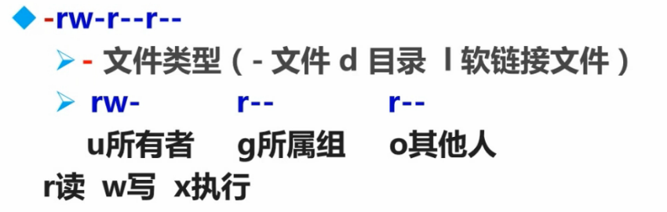

- 打开文件  
  open()
- 读取  
  read()  
  readline()  
  readlines():读完文件，返回每一行的列表。
- 写入  
  write(str)  
  writelines()

```python
f = open('test.py')
```

```python
type(f)
```

```
_io.TextIOWrapper
```

```python
dir(f) #查看拥有的方法
```

```
['_CHUNK_SIZE',
 '__class__',
 '__del__',
 '__delattr__',
 '__dict__',
 '__dir__',
 '__doc__',
 '__enter__',
 '__eq__',
 '__exit__',
 '__format__',
 '__ge__',
 '__getattribute__',
 '__getstate__',
 '__gt__',
 '__hash__',
 '__init__',
 '__init_subclass__',
 '__iter__',
 '__le__',
 '__lt__',
 '__ne__',
 '__new__',
 '__next__',
 '__reduce__',
 '__reduce_ex__',
 '__repr__',
 '__setattr__',
 '__sizeof__',
 '__str__',
 '__subclasshook__',
 '_checkClosed',
 '_checkReadable',
 '_checkSeekable',
 '_checkWritable',
 '_finalizing',
 'buffer',
 'close',
 'closed',
 'detach',
 'encoding',
 'errors',
 'fileno',
 'flush',
 'isatty',
 'line_buffering',
 'mode',
 'name',
 'newlines',
 'read',
 'readable',
 'readline',
 'readlines',
 'reconfigure',
 'seek',
 'seekable',
 'tell',
 'truncate',
 'writable',
 'write',
 'write_through',
 'writelines']
```

```python
c = f.read() #查看内容, 返回str
c
```

```
'import this \n\n'
```

```python
type(c)
```

```
str
```

### python 打开方式

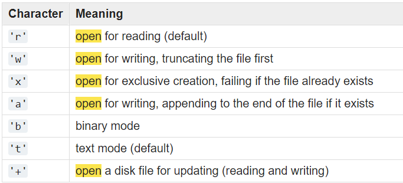

```python
f.write("#hello") # 默认只读打开文件
```

```
---------------------------------------------------------------------------
UnsupportedOperation                      Traceback (most recent call last)
<ipython-input-13-bc476f88675c> in <module>
----> 1 f.write("#hello") # 默认只读打开文件

UnsupportedOperation: not writable
```

```python
f1 = open('1.txt') #只读方式，不能打开不存在的文件
```

```
---------------------------------------------------------------------------
FileNotFoundError                         Traceback (most recent call last)
<ipython-input-15-228cd2cba805> in <module>
----> 1 f1 = open('1.txt') #只读方式，不能打开不存在的文件

FileNotFoundError: [Errno 2] No such file or directory: '1.txt'
```

```python
f1 = open('1.txt','w') #只写方式可以打开。
#如果文件存在，会被清空
f1.write('write test')
f1.close()
```

```
10
```

```python
!cat 1.txt
```

[output not shown]

```python
f2 = open('1.txt','a')
f2.write('append test')
f2.close()
```

```
11
```

### 文件的读取方式

```python
!cat 1.txt
```

```
write testappend test
hello
world
```

```python
f = open('1.txt')
f.read() # 读取全部内容, 可输入字节
```

```
'write testappend test\nhello\nworld'
```

```python
f.readline() #已经访问到尾部
```

```
''
```

```python
f.close()
```

```python
f = open('1.txt')
f.readline(5) #读取第一行的5个字节
```

```
'write'
```

```python
f.readline() #读取剩下的第一行
```

```
' testappend test\n'
```

```python
f.readlines() #读取剩下的两行，并组成列表
```

```
['hello\n', 'world']
```

```python
help(f.readlines) # hint的作用
```

```
Help on built-in function readlines:

readlines(hint=-1, /) method of _io.TextIOWrapper instance
    Return a list of lines from the stream.

    hint can be specified to control the number of lines read: no more
    lines will be read if the total size (in bytes/characters) of all
    lines so far exceeds hint.
```

```python
import io
io.DEFAULT_BUFFER_SIZE
```

```
8192
```

```python
f.close()
```

```python
f = open('1.txt')
iter_f = iter(f)
for i in iter_f:
    print(i)
len(list(iter_f))#转化为list之后求行数,读取之后为空
```

```
write testappend test

hello

world
```

```
0
```

迭代器，节省内存，完成对文件的遍历

```python
iter_f
```

```
<_io.TextIOWrapper name='1.txt' mode='r' encoding='UTF-8'>
```

```python
list(iter_f)
```

```
[]
```

```python
f.close()
```

### 写入方式

write(str)  
writelines(lines)

```python
f = open('1.txt','+') # 不能单独使用+
```

```
---------------------------------------------------------------------------
ValueError                                Traceback (most recent call last)
<ipython-input-44-ec44b0ff3340> in <module>
----> 1 f = open('1.txt','+') # 不能单独使用+

ValueError: Must have exactly one of create/read/write/append mode and at most one plus
```

```python
f = open('1.txt','r+') # 从第一行开始写，并修改原来的内容。
```

```python
f.write('test open r+ mode')
f.close()
```

```
17
```

```python
!cat 1.txt
```

```
test open r+ modetest
hello
world
```

linux有写缓存机制，只有在close()时才会完成写入。

1。 主动调用close(),flush(), 写缓存同步到磁盘。  
2。 写入数据量大于等于写缓存时，也会同步到磁盘。

### 文件关闭

1。将写缓存同步到磁盘。  
2。linux系统中每个进程打开文件的个数是有限的。

```python
!ps
```

```
  PID TTY          TIME CMD
 1883 pts/4    00:00:00 sh
 1884 pts/4    00:00:00 ps
```

```python
!python & #不支持后台操作
```

### 文件指针

1。写入文件后，必须打开才能读取写入内容。  
2。读取文件后，必须重新再次读取读过的内容。

文件指针的移动过程

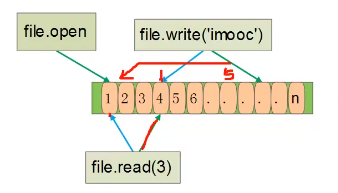

os.SEEK_SET:0, start  
os.SEEK_CUR:1, current  
os.SEEK_END:2, end

```python
f = open('1.txt','r+') # 必须先定义f, 才能在help中使用。
help(f.tell)
```

```
Help on built-in function tell:

tell() method of _io.TextIOWrapper instance
    Return current stream position.
```

```python
f.tell()
```

```
0
```

```python
f.read(3) #执行一次走3位。
f.tell()
```

```
't o'
```

```
6
```

```python
import os
f.seek(0,os.SEEK_SET) #回到文件首部，移动不能越界。
f.tell()
```

```
0
```

```
0
```

## 文件属性

```python
f = open('1.txt')
f.fileno() #文件描述符
```

```
45
```

```python
f.mode #文件打开权限
```

```
'r'
```

```python
f.closed #文件打开权限
```

```
False
```

```python
f.encoding #文件编码格式
```

```
'UTF-8'
```

### 标准文件

文件标准输入：sys.stdin  
文件标准输出：sys.stdout  
文件标准错误：sys.stderr;

```python
import sys
type(sys.stdin)
```

```
_io.TextIOWrapper
```

```python
sys.stdin.mode # 只读文件
```

```
'r'
```

```python
sys.stdin.fileno() #第一个打开的文件
```

```
0
```

```python
a = raw_input(":") #python3中取消
```

```
---------------------------------------------------------------------------
NameError                                 Traceback (most recent call last)
<ipython-input-20-c4e6c9814b1e> in <module>
----> 1 a = raw_input(":")

NameError: name 'raw_input' is not defined
```

```python
a = input(":") # 会调用stdin.
```

```
:hello world
```

```python
a
```

```
'hello world'
```

```python
type(sys.stdout) # <class '_io.TextIOWrapper'>,与终端不同
```

```
ipykernel.iostream.OutStream
```

```python
sys.stdout.write('1000') #print 会调用这个
```

```
1000
```

```python
sys.stdout.fileno() # 与python2不同
```

```
---------------------------------------------------------------------------
UnsupportedOperation                      Traceback (most recent call last)
<ipython-input-26-76a8ceee4d27> in <module>
----> 1 sys.stdout.fileno()

UnsupportedOperation: fileno
```

```python
type(sys.stderr) # <class '_io.TextIOWrapper'>
```

```
ipykernel.iostream.OutStream
```

```python
sys.stderr.fileno() # 与终端不同
```

```
---------------------------------------------------------------------------
UnsupportedOperation                      Traceback (most recent call last)
<ipython-input-28-eec0ad53e5c0> in <module>
----> 1 sys.stderr.fileno()

UnsupportedOperation: fileno
```

通过 sys.argv and取命令行参数

```python
%run test.py 0 1 2 3 'hello' #一种6个参数
```

```
6
test.py
0
1
2
3
hello
```

```python
f = open('1.txt','r+')
f.write(123) # 必须写入str
```

```
---------------------------------------------------------------------------
TypeError                                 Traceback (most recent call last)
<ipython-input-33-e63ffc30ad54> in <module>
      1 f = open('1.txt','r+')
----> 2 f.write(123)

TypeError: write() argument must be str, not int
```

```python
f.write('123')
```

```
3
```

```python
f.write('慕课') # 已经是utf-8
```

```
2
```

```python
f.close()
!cat 1.txt
```

```
123慕课 r+ modetest
hello
world
```

```python
import codecs
help(codecs.open) #需要先引入再使用
```

```
Help on function open in module codecs:

open(filename, mode='r', encoding=None, errors='strict', buffering=1)
    Open an encoded file using the given mode and return
    a wrapped version providing transparent encoding/decoding.

    Note: The wrapped version will only accept the object format
    defined by the codecs, i.e. Unicode objects for most builtin
    codecs. Output is also codec dependent and will usually be
    Unicode as well.

    Underlying encoded files are always opened in binary mode.
    The default file mode is 'r', meaning to open the file in read mode.

    encoding specifies the encoding which is to be used for the
    file.

    errors may be given to define the error handling. It defaults
    to 'strict' which causes ValueErrors to be raised in case an
    encoding error occurs.

    buffering has the same meaning as for the builtin open() API.
    It defaults to line buffered.

    The returned wrapped file object provides an extra attribute
    .encoding which allows querying the used encoding. This
    attribute is only available if an encoding was specified as
    parameter.
```

### 使用os模块打开文件

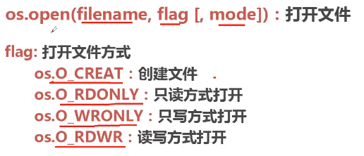

```python
import os
fd = os.open('1.txt',os.O_CREAT| os.O_RDWR)
```

```python
!ls -l
```

```
总用量 772
-rwxrwxrwx 1 yichang yichang     33 7月  18 15:08  1.txt
-rwxrwxrwx 1 yichang yichang   4779 7月  17 14:40  jupyter使用技巧.ipynb
-rwxrwxrwx 1 yichang yichang 170565 7月  18 15:16 'Linux 常用命令.ipynb'
-rwxrwxrwx 1 yichang yichang    123 7月  18 15:04  test.py
-rwxrwxrwx 1 yichang yichang  26533 7月  16 12:52  基础知识-list-str-tuple-dict.ipynb
-rwxrwxrwx 1 yichang yichang 106868 7月  15 14:36  基础知识-变量等.ipynb
-rwxrwxrwx 1 yichang yichang  38044 7月  17 16:59  基础知识-函数.ipynb
-rwxrwxrwx 1 yichang yichang   5342 7月  15 15:30  基础知识-语法.ipynb
-rwxrwxrwx 1 yichang yichang  29979 7月  18 12:10  进阶-对象与类.ipynb
-rwxrwxrwx 1 yichang yichang   7797 7月  17 11:49  进阶-模块与包.ipynb
-rwxrwxrwx 1 yichang yichang 375551 7月  18 15:19  进阶-文件.ipynb
-rwxrwxrwx 1 yichang yichang   1931 7月  17 16:31  算法小模块.ipynb
```

```python
n = os.write(fd,b'os.write') # python3 只能输入bytes
l = os.lseek(fd,0, os.SEEK_SET)
str1 = os.read(fd, 8)
str1
```

```
b'os.write'
```

```python
os.close(fd)
```

os 模块的其他方法

```python
os.access('1.txt',os.F_OK) #判断文件是否存在
```

```
True
```

```python
os.access('1.txt',os.R_OK),os.access('1.txt',os.W_OK),os.access('1.txt',os.X_OK) # 是否有读写执行的权限
```

```
(True, True, True)
```

```python
os.listdir('./') #返回目录列表
```

```
['.ipynb_checkpoints',
 '.vscode',
 '1.txt',
 'jupyter使用技巧.ipynb',
 'Linux 常用命令.ipynb',
 'test.py',
 '基础知识-list-str-tuple-dict.ipynb',
 '基础知识-函数.ipynb',
 '基础知识-变量等.ipynb',
 '基础知识-语法.ipynb',
 '算法小模块.ipynb',
 '进阶-对象与类.ipynb',
 '进阶-文件.ipynb',
 '进阶-模块与包.ipynb']
```

```python
os.rename('1.txt','2.txt')
os.listdir('./')
```

```
['.ipynb_checkpoints',
 '.vscode',
 '2.txt',
 'jupyter使用技巧.ipynb',
 'Linux 常用命令.ipynb',
 'test.py',
 '基础知识-list-str-tuple-dict.ipynb',
 '基础知识-函数.ipynb',
 '基础知识-变量等.ipynb',
 '基础知识-语法.ipynb',
 '算法小模块.ipynb',
 '进阶-对象与类.ipynb',
 '进阶-文件.ipynb',
 '进阶-模块与包.ipynb']
```

```python
os.mkdir('3.txt') # 创建目录或者文件
os.listdir('./')
```

```
['.ipynb_checkpoints',
 '.vscode',
 '2.txt',
 '3.txt',
 'jupyter使用技巧.ipynb',
 'Linux 常用命令.ipynb',
 'test.py',
 '基础知识-list-str-tuple-dict.ipynb',
 '基础知识-函数.ipynb',
 '基础知识-变量等.ipynb',
 '基础知识-语法.ipynb',
 '算法小模块.ipynb',
 '进阶-对象与类.ipynb',
 '进阶-文件.ipynb',
 '进阶-模块与包.ipynb']
```

```python
os.path.exists('2.txt') #判断路径是否存在
```

```
True
```

```python
os.path.isdir('.vscode/') #判断是否为目录
```

```
True
```

```python
os.path.isfile('2.txt') #
```

```
True
```

```python
os.path.getsize('2.txt')
```

```
33
```

```python
os.path.dirname('2.txt')
```

```
''
```

使用python 管理ini配置文件

```python
import configparser

cfg = configparser.ConfigParser()
```

```python
cfg.read('ini.txt')
```

```
['ini.txt']
```

```python
cfg.sections()
```

```
['userinfo', 'study']
```

```python
for se in cfg.sections():
    print(se)
    print(cfg.items(se))
```

```
userinfo
[('name', 'zhangsan'), ('pwd', 'abc')]
study
[('python base', '15'), ('python junior', '20'), ('linux base', '15')]
```

```python
cfg.set('userinfo','pwd','123456')
```

```python
for se in cfg.sections():
    print(se)
    print(cfg.items(se))
```

```
userinfo
[('name', 'zhangsan'), ('pwd', '123456')]
study
[('python base', '15'), ('python junior', '20'), ('linux base', '15')]
```

```python
cfg.set('userinfo','email','123456@qq.com')
for se in cfg.sections():
    print(se)
    print(cfg.items(se))
```

```
userinfo
[('name', 'zhangsan'), ('pwd', '123456'), ('email', '123456@qq.com')]
study
[('python base', '15'), ('python junior', '20'), ('linux base', '15')]
```

```python
cfg.remove_option('userinfo','email')
for se in cfg.sections():
    print(se)
    print(cfg.items(se))
```

```
True
```

```
userinfo
[('name', 'zhangsan'), ('pwd', '123456')]
study
[('python base', '15'), ('python junior', '20'), ('linux base', '15')]
```